# ChIP-seq: introduction; Bioconductor

March 25, 2019

## Today's topics

- Intro to functional genomics assays to study transcriptional regulation and epigenetics
  - ChIP-seq (ChIP-exo, ChIP-nexus, Cut&Run)
  - ATAC-seq (DNase-seq, MNase-seq, FAIRE-seq)
  - Hi-C (HiChIP, ChIA-PET)
- Bioconductor infrastructure for analysis of genomic data
  - BED and GFF file formats for genomic intervals and annotations
  - `GenomicRanges` for genomic intervals
  - `GenomicFeatures`, `AnnotationDbi` for genomic annotations
  - `Biostrings`, `BSgenome` for genomic sequences

## Functional genomics assays for transcriptional regulation and epigenetics

## Transcriptional regulation and epigenetics

- Cells with identical or nearly identical genomes in the organism have very different phenotypes and gene expression profiles
- Could be explained by epigenetic differences:
  - differences in transcription factor and other protein binding to chromatin
  - DNA modifications (methylation)
  - histone modifications
  - chromatin accessibility
  - chromatin interactions in 3D
- Sequencing-based assays to study transcriptional regulation and epigenetics

## Protein binding or histone modifications

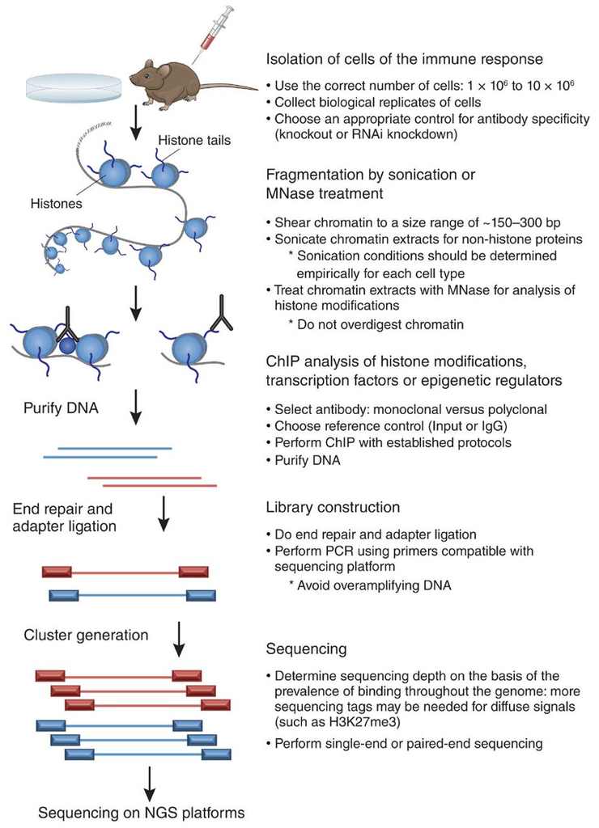

- ChIP-seq; also: ChIP-nexus, ChIP-exo, Cut&Run

## Chromatin accessibility

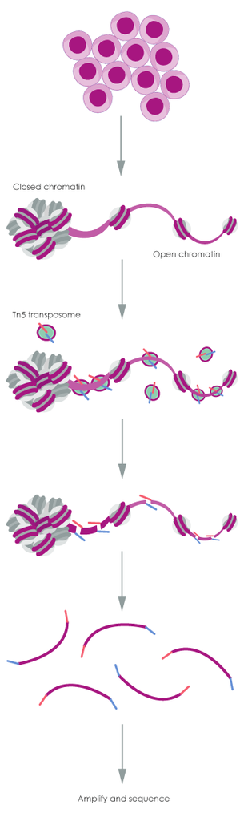

- ATAC-seq; also: DNase-seq, MNase-seq, FAIRE-seq

## Chromatin interactions

[figure not shown]

- Hi-C; also: HiChIP, ChIA-PET

## Sequencing-based assays

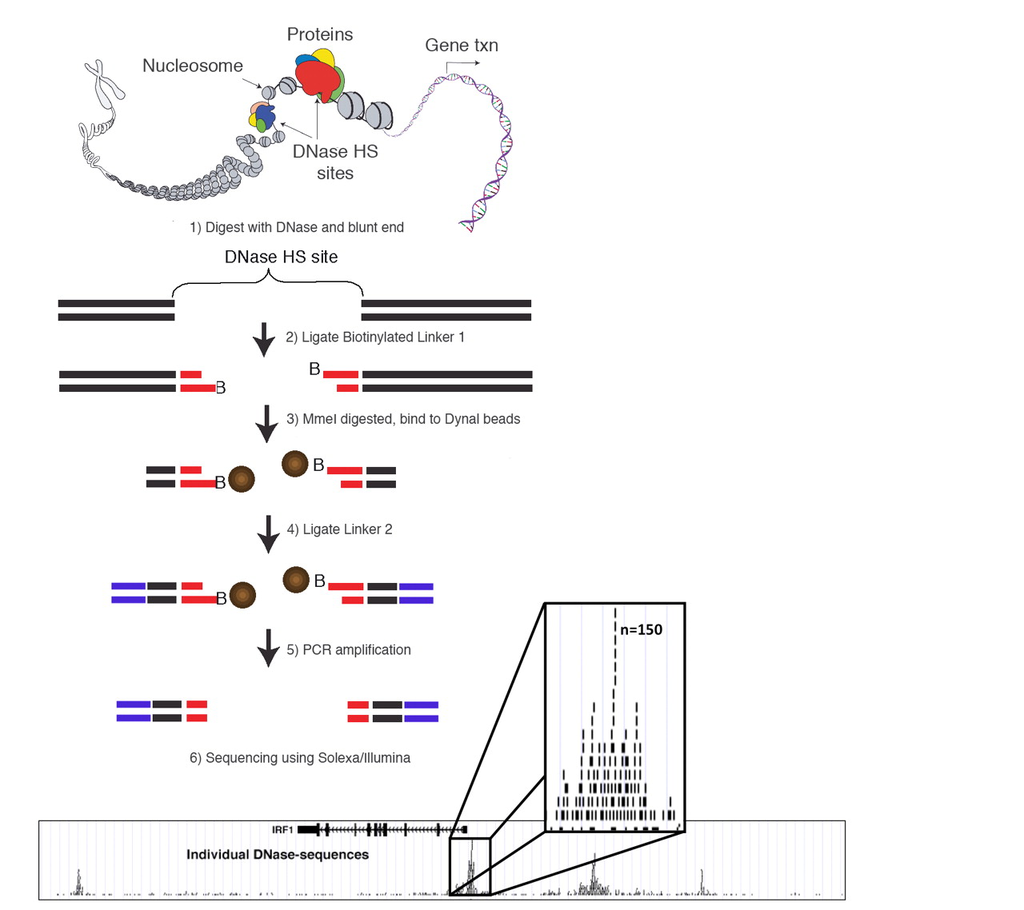

## Genomic intervals and annotations

## File formats

- BED
  - Browser Extensible Data
  - tab-delimited
  - required fields: chrom, chromStart, chromEnd
  - optional fields: name, score, strand, etc.
- GFF/GTF
  - General Feature Format / General Transfer Format
  - tab-delimited
  - required fields: seqname, source, feature, start, end, score, strand, frame, attribute

## Bioconductor infrastructure

## Bioconductor packages and data types

- `GenomicRanges` for genomic intervals
- `GenomicFeatures`, `AnnotationDbi` for genomic annotations
- `Biostrings`, `BSgenome` for genomic sequences